# Netflix Exploratory Data Analysis

```python
import pandas as pd
import numpy as np
import matplotlib.pyplot as plt
import seaborn as sns
import warnings
warnings.filterwarnings('ignore')
%matplotlib inline
```

## 1. Import Data

```python
df = pd.read_csv('netflix.csv')
```

```python
df.head(5)
```

|  | show_id | type | title | director | cast | country | date_added | release_year | rating | duration | listed_in | description |
| --- | --- | --- | --- | --- | --- | --- | --- | --- | --- | --- | --- | --- |
| 0 | s1 | Movie | Dick Johnson Is Dead | Kirsten Johnson | NaN | United States | September 25, 2021 | 2020 | PG-13 | 90 min | Documentaries | As her father nears the end of his life, filmm... |
| 1 | s2 | TV Show | Blood & Water | NaN | Ama Qamata, Khosi Ngema, Gail Mabalane, Thaban... | South Africa | September 24, 2021 | 2021 | TV-MA | 2 Seasons | International TV Shows, TV Dramas, TV Mysteries | After crossing paths at a party, a Cape Town t... |
| 2 | s3 | TV Show | Ganglands | Julien Leclercq | Sami Bouajila, Tracy Gotoas, Samuel Jouy, Nabi... | NaN | September 24, 2021 | 2021 | TV-MA | 1 Season | Crime TV Shows, International TV Shows, TV Act... | To protect his family from a powerful drug lor... |
| 3 | s4 | TV Show | Jailbirds New Orleans | NaN | NaN | NaN | September 24, 2021 | 2021 | TV-MA | 1 Season | Docuseries, Reality TV | Feuds, flirtations and toilet talk go down amo... |
| 4 | s5 | TV Show | Kota Factory | NaN | Mayur More, Jitendra Kumar, Ranjan Raj, Alam K... | India | September 24, 2021 | 2021 | TV-MA | 2 Seasons | International TV Shows, Romantic TV Shows, TV ... | In a city of coaching centers known to train I... |

```python
df.tail(5)
```

|  | show_id | type | title | director | cast | country | date_added | release_year | rating | duration | listed_in | description |
| --- | --- | --- | --- | --- | --- | --- | --- | --- | --- | --- | --- | --- |
| 8802 | s8803 | Movie | Zodiac | David Fincher | Mark Ruffalo, Jake Gyllenhaal, Robert Downey J... | United States | November 20, 2019 | 2007 | R | 158 min | Cult Movies, Dramas, Thrillers | A political cartoonist, a crime reporter and a... |
| 8803 | s8804 | TV Show | Zombie Dumb | NaN | NaN | NaN | July 1, 2019 | 2018 | TV-Y7 | 2 Seasons | Kids' TV, Korean TV Shows, TV Comedies | While living alone in a spooky town, a young g... |
| 8804 | s8805 | Movie | Zombieland | Ruben Fleischer | Jesse Eisenberg, Woody Harrelson, Emma Stone, ... | United States | November 1, 2019 | 2009 | R | 88 min | Comedies, Horror Movies | Looking to survive in a world taken over by zo... |
| 8805 | s8806 | Movie | Zoom | Peter Hewitt | Tim Allen, Courteney Cox, Chevy Chase, Kate Ma... | United States | January 11, 2020 | 2006 | PG | 88 min | Children & Family Movies, Comedies | Dragged from civilian life, a former superhero... |
| 8806 | s8807 | Movie | Zubaan | Mozez Singh | Vicky Kaushal, Sarah-Jane Dias, Raaghav Chanan... | India | March 2, 2019 | 2015 | TV-14 | 111 min | Dramas, International Movies, Music & Musicals | A scrappy but poor boy worms his way into a ty... |

```python
df.columns
```

```
Index(['show_id', 'type', 'title', 'director', 'cast', 'country', 'date_added',
       'release_year', 'rating', 'duration', 'listed_in', 'description'],
      dtype='object')
```

```python
df.shape
```

```
(8807, 12)
```

```python
df.info()
```

```
<class 'pandas.core.frame.DataFrame'>
RangeIndex: 8807 entries, 0 to 8806
Data columns (total 12 columns):
 #   Column        Non-Null Count  Dtype
---  ------        --------------  -----
 0   show_id       8807 non-null   object
 1   type          8807 non-null   object
 2   title         8807 non-null   object
 3   director      6173 non-null   object
 4   cast          7982 non-null   object
 5   country       7976 non-null   object
 6   date_added    8797 non-null   object
 7   release_year  8807 non-null   int64
 8   rating        8803 non-null   object
 9   duration      8804 non-null   object
 10  listed_in     8807 non-null   object
 11  description   8807 non-null   object
dtypes: int64(1), object(11)
memory usage: 825.8+ KB
```

```python
df.describe()
```

|  | release_year |
| --- | --- |
| count | 8807.000000 |
| mean | 2014.180198 |
| std | 8.819312 |
| min | 1925.000000 |
| 25% | 2013.000000 |
| 50% | 2017.000000 |
| 75% | 2019.000000 |
| max | 2021.000000 |

```python
df.describe(include='object')
```

|  | show_id | type | title | director | cast | country | date_added | rating | duration | listed_in | description |
| --- | --- | --- | --- | --- | --- | --- | --- | --- | --- | --- | --- |
| count | 8807 | 8807 | 8807 | 6173 | 7982 | 7976 | 8797 | 8803 | 8804 | 8807 | 8807 |
| unique | 8807 | 2 | 8807 | 4528 | 7692 | 748 | 1767 | 17 | 220 | 514 | 8775 |
| top | s8807 | Movie | Zubaan | Rajiv Chilaka | David Attenborough | United States | January 1, 2020 | TV-MA | 1 Season | Dramas, International Movies | Paranormal activity at a lush, abandoned prope... |
| freq | 1 | 6131 | 1 | 19 | 19 | 2818 | 109 | 3207 | 1793 | 362 | 4 |

```python
df.describe(include='all')
```

|  | show_id | type | title | director | cast | country | date_added | release_year | rating | duration | listed_in | description |
| --- | --- | --- | --- | --- | --- | --- | --- | --- | --- | --- | --- | --- |
| count | 8807 | 8807 | 8807 | 6173 | 7982 | 7976 | 8797 | 8807.000000 | 8803 | 8804 | 8807 | 8807 |
| unique | 8807 | 2 | 8807 | 4528 | 7692 | 748 | 1767 | NaN | 17 | 220 | 514 | 8775 |
| top | s8807 | Movie | Zubaan | Rajiv Chilaka | David Attenborough | United States | January 1, 2020 | NaN | TV-MA | 1 Season | Dramas, International Movies | Paranormal activity at a lush, abandoned prope... |
| freq | 1 | 6131 | 1 | 19 | 19 | 2818 | 109 | NaN | 3207 | 1793 | 362 | 4 |
| mean | NaN | NaN | NaN | NaN | NaN | NaN | NaN | 2014.180198 | NaN | NaN | NaN | NaN |
| std | NaN | NaN | NaN | NaN | NaN | NaN | NaN | 8.819312 | NaN | NaN | NaN | NaN |
| min | NaN | NaN | NaN | NaN | NaN | NaN | NaN | 1925.000000 | NaN | NaN | NaN | NaN |
| 25% | NaN | NaN | NaN | NaN | NaN | NaN | NaN | 2013.000000 | NaN | NaN | NaN | NaN |
| 50% | NaN | NaN | NaN | NaN | NaN | NaN | NaN | 2017.000000 | NaN | NaN | NaN | NaN |
| 75% | NaN | NaN | NaN | NaN | NaN | NaN | NaN | 2019.000000 | NaN | NaN | NaN | NaN |
| max | NaN | NaN | NaN | NaN | NaN | NaN | NaN | 2021.000000 | NaN | NaN | NaN | NaN |

```python
df.sample()
```

|  | show_id | type | title | director | cast | country | date_added | release_year | rating | duration | listed_in | description |
| --- | --- | --- | --- | --- | --- | --- | --- | --- | --- | --- | --- | --- |
| 3530 | s3531 | Movie | Article 15 | Anubhav Sinha | Ayushmann Khurrana, Nassar, Manoj Pahwa, Kumud... | India | September 6, 2019 | 2019 | TV-MA | 125 min | Dramas, International Movies, Thrillers | The grim realities of caste discrimination com... |

```python
df.dtypes
```

```
show_id         object
type            object
title           object
director        object
cast            object
country         object
date_added      object
release_year     int64
rating          object
duration        object
listed_in       object
description     object
dtype: object
```

```python
df[df.duplicated()]
```

|  | show_id | type | title | director | cast | country | date_added | release_year | rating | duration | listed_in | description |
| --- | --- | --- | --- | --- | --- | --- | --- | --- | --- | --- | --- | --- |

## 2. Data Wrangling

### > Unnesting the columns (directors , casts , countrys , listed_in)

```python
unnesting = ['director', 'cast', 'listed_in','country']
for column in unnesting:
    df[column] = df[column].str.split(', ')
    df = df.explode(column)
```

```python
df.head(5)
```

|  | show_id | type | title | director | cast | country | date_added | release_year | rating | duration | listed_in | description |
| --- | --- | --- | --- | --- | --- | --- | --- | --- | --- | --- | --- | --- |
| 0 | s1 | Movie | Dick Johnson Is Dead | Kirsten Johnson | NaN | United States | September 25, 2021 | 2020 | PG-13 | 90 min | Documentaries | As her father nears the end of his life, filmm... |
| 1 | s2 | TV Show | Blood & Water | NaN | Ama Qamata | South Africa | September 24, 2021 | 2021 | TV-MA | 2 Seasons | International TV Shows | After crossing paths at a party, a Cape Town t... |
| 1 | s2 | TV Show | Blood & Water | NaN | Ama Qamata | South Africa | September 24, 2021 | 2021 | TV-MA | 2 Seasons | TV Dramas | After crossing paths at a party, a Cape Town t... |
| 1 | s2 | TV Show | Blood & Water | NaN | Ama Qamata | South Africa | September 24, 2021 | 2021 | TV-MA | 2 Seasons | TV Mysteries | After crossing paths at a party, a Cape Town t... |
| 1 | s2 | TV Show | Blood & Water | NaN | Khosi Ngema | South Africa | September 24, 2021 | 2021 | TV-MA | 2 Seasons | International TV Shows | After crossing paths at a party, a Cape Town t... |

```python
df.shape
```

```
(201991, 12)
```

```python
df.dtypes
```

```
show_id         object
type            object
title           object
director        object
cast            object
country         object
date_added      object
release_year     int64
rating          object
duration        object
listed_in       object
description     object
dtype: object
```

```python
df.reset_index(drop=True,inplace=True)
```

```python
df
```

|  | show_id | type | title | director | cast | country | date_added | release_year | rating | duration | listed_in | description |
| --- | --- | --- | --- | --- | --- | --- | --- | --- | --- | --- | --- | --- |
| 0 | s1 | Movie | Dick Johnson Is Dead | Kirsten Johnson | NaN | United States | September 25, 2021 | 2020 | PG-13 | 90 min | Documentaries | As her father nears the end of his life, filmm... |
| 1 | s2 | TV Show | Blood & Water | NaN | Ama Qamata | South Africa | September 24, 2021 | 2021 | TV-MA | 2 Seasons | International TV Shows | After crossing paths at a party, a Cape Town t... |
| 2 | s2 | TV Show | Blood & Water | NaN | Ama Qamata | South Africa | September 24, 2021 | 2021 | TV-MA | 2 Seasons | TV Dramas | After crossing paths at a party, a Cape Town t... |
| 3 | s2 | TV Show | Blood & Water | NaN | Ama Qamata | South Africa | September 24, 2021 | 2021 | TV-MA | 2 Seasons | TV Mysteries | After crossing paths at a party, a Cape Town t... |
| 4 | s2 | TV Show | Blood & Water | NaN | Khosi Ngema | South Africa | September 24, 2021 | 2021 | TV-MA | 2 Seasons | International TV Shows | After crossing paths at a party, a Cape Town t... |
| ... | ... | ... | ... | ... | ... | ... | ... | ... | ... | ... | ... | ... |
| 201986 | s8807 | Movie | Zubaan | Mozez Singh | Anita Shabdish | India | March 2, 2019 | 2015 | TV-14 | 111 min | International Movies | A scrappy but poor boy worms his way into a ty... |
| 201987 | s8807 | Movie | Zubaan | Mozez Singh | Anita Shabdish | India | March 2, 2019 | 2015 | TV-14 | 111 min | Music & Musicals | A scrappy but poor boy worms his way into a ty... |
| 201988 | s8807 | Movie | Zubaan | Mozez Singh | Chittaranjan Tripathy | India | March 2, 2019 | 2015 | TV-14 | 111 min | Dramas | A scrappy but poor boy worms his way into a ty... |
| 201989 | s8807 | Movie | Zubaan | Mozez Singh | Chittaranjan Tripathy | India | March 2, 2019 | 2015 | TV-14 | 111 min | International Movies | A scrappy but poor boy worms his way into a ty... |
| 201990 | s8807 | Movie | Zubaan | Mozez Singh | Chittaranjan Tripathy | India | March 2, 2019 | 2015 | TV-14 | 111 min | Music & Musicals | A scrappy but poor boy worms his way into a ty... |

201991 rows × 12 columns

#### 👉Insights :

Note after unnesting the no.of movies and TvShows rows are increased but still we use nunique() instead of counts to get the accurate data...

- Movie - 6131
- TV Show - 2676
- Total - 8807

#### Dealing with NULL

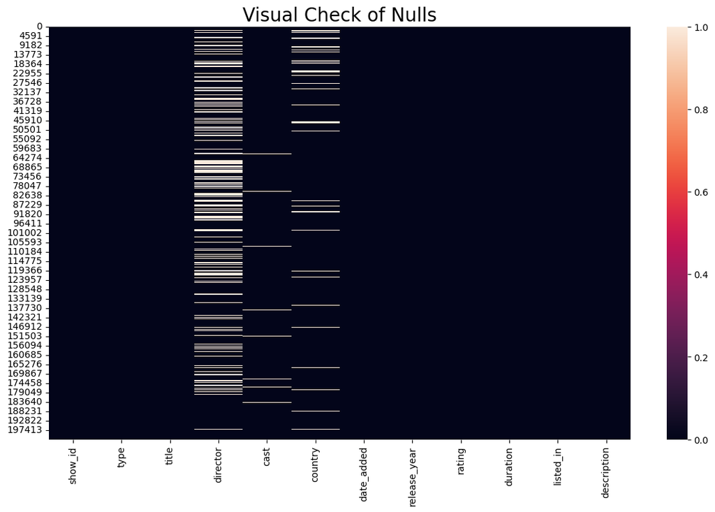

```python
plt.figure(figsize=(14,8))
sns.heatmap(df.isnull())
plt.title('Visual Check of Nulls',fontsize=20)
plt.show()
```

```python
df.isna().sum().sort_values(ascending=False)
```

```
director        50643
country         11897
cast             2146
date_added        158
rating             67
duration            3
show_id             0
type                0
title               0
release_year        0
listed_in           0
description         0
dtype: int64
```

```python
for i in df.columns:
    null_pct = (df[i].isna().sum() / df.shape[0]) *100
    if null_pct > 0 :
        print(f'Null_Percentage of {i} is {round(null_pct,3)} %')
```

```
Null_Percentage of director is 25.072 %
Null_Percentage of cast is 1.062 %
Null_Percentage of country is 5.89 %
Null_Percentage of date_added is 0.078 %
Null_Percentage of rating is 0.033 %
Null_Percentage of duration is 0.001 %
```

#### Change Date Representation

```python
df.sample()
```

|  | show_id | type | title | director | cast | country | date_added | release_year | rating | duration | listed_in | description |
| --- | --- | --- | --- | --- | --- | --- | --- | --- | --- | --- | --- | --- |
| 172664 | s7578 | Movie | Neruda | Pablo Larraín | Luis Gnecco | Chile | June 26, 2017 | 2016 | R | 108 min | International Movies | When a Chilean policeman vows to find and capt... |

```python
df['date_added'] = pd.to_datetime(df['date_added'] ,format="%B %d, %Y" , errors='coerce')
```

```python
df.sample()
```

|  | show_id | type | title | director | cast | country | date_added | release_year | rating | duration | listed_in | description |
| --- | --- | --- | --- | --- | --- | --- | --- | --- | --- | --- | --- | --- |
| 154688 | s6841 | Movie | Get Santa | Christopher Smith | Ewen Bremner | United Kingdom | 2014-12-12 | 2014 | PG | 103 min | Comedies | When Santa gets arrested for trespassing after... |

```python
df['date_added'].fillna(df['date_added'].mode()[0], inplace=True)
```

```python
df.isna().sum().sort_values(ascending=False)
```

```
director        50643
country         11897
cast             2146
rating             67
duration            3
title               0
show_id             0
type                0
release_year        0
date_added          0
listed_in           0
description         0
dtype: int64
```

```python
df.dtypes
```

```
show_id                 object
type                    object
title                   object
director                object
cast                    object
country                 object
date_added      datetime64[ns]
release_year             int64
rating                  object
duration                object
listed_in               object
description             object
dtype: object
```

```python
df['year_added'] = df['date_added'].dt.year
```

```python
df.sample()
```

|  | show_id | type | title | director | cast | country | date_added | release_year | rating | duration | listed_in | description | year_added |
| --- | --- | --- | --- | --- | --- | --- | --- | --- | --- | --- | --- | --- | --- |
| 157854 | s6958 | Movie | Hellboy | Guillermo del Toro | Ron Perlman | United States | 2018-12-01 | 2004 | PG-13 | 122 min | Action & Adventure | This fast-paced action flick tells the dark st... | 2018 |

```python
df.dtypes
```

```
show_id                 object
type                    object
title                   object
director                object
cast                    object
country                 object
date_added      datetime64[ns]
release_year             int64
rating                  object
duration                object
listed_in               object
description             object
year_added               int32
dtype: object
```

```python
df.shape
```

```
(201991, 13)
```

```python
df.info()
```

```
<class 'pandas.core.frame.DataFrame'>
RangeIndex: 201991 entries, 0 to 201990
Data columns (total 13 columns):
 #   Column        Non-Null Count   Dtype
---  ------        --------------   -----
 0   show_id       201991 non-null  object
 1   type          201991 non-null  object
 2   title         201991 non-null  object
 3   director      151348 non-null  object
 4   cast          199845 non-null  object
 5   country       190094 non-null  object
 6   date_added    201991 non-null  datetime64[ns]
 7   release_year  201991 non-null  int64
 8   rating        201924 non-null  object
 9   duration      201988 non-null  object
 10  listed_in     201991 non-null  object
 11  description   201991 non-null  object
 12  year_added    201991 non-null  int32
dtypes: datetime64[ns](1), int32(1), int64(1), object(10)
memory usage: 19.3+ MB
```

```python
df.isna().sum().sort_values(ascending=False)
```

```
director        50643
country         11897
cast             2146
rating             67
duration            3
type                0
title               0
show_id             0
date_added          0
release_year        0
listed_in           0
description         0
year_added          0
dtype: int64
```

```python
df[df.rating.isna() | df.duration.isna()]
```

|  | show_id | type | title | director | cast | country | date_added | release_year | rating | duration | listed_in | description | year_added |
| --- | --- | --- | --- | --- | --- | --- | --- | --- | --- | --- | --- | --- | --- |
| 126537 | s5542 | Movie | Louis C.K. 2017 | Louis C.K. | Louis C.K. | United States | 2017-04-04 | 2017 | 74 min | NaN | Movies | Louis C.K. muses on religion, eternal love, gi... | 2017 |
| 131603 | s5795 | Movie | Louis C.K.: Hilarious | Louis C.K. | Louis C.K. | United States | 2016-09-16 | 2010 | 84 min | NaN | Movies | Emmy-winning comedy writer Louis C.K. brings h... | 2016 |
| 131737 | s5814 | Movie | Louis C.K.: Live at the Comedy Store | Louis C.K. | Louis C.K. | United States | 2016-08-15 | 2015 | 66 min | NaN | Movies | The comic puts his trademark hilarious/thought... | 2016 |
| 135125 | s5990 | Movie | 13TH: A Conversation with Oprah Winfrey & Ava ... | NaN | Oprah Winfrey | NaN | 2017-01-26 | 2017 | NaN | 37 min | Movies | Oprah Winfrey sits down with director Ava DuVe... | 2017 |
| 135126 | s5990 | Movie | 13TH: A Conversation with Oprah Winfrey & Ava ... | NaN | Ava DuVernay | NaN | 2017-01-26 | 2017 | NaN | 37 min | Movies | Oprah Winfrey sits down with director Ava DuVe... | 2017 |
| ... | ... | ... | ... | ... | ... | ... | ... | ... | ... | ... | ... | ... | ... |
| 171942 | s7538 | Movie | My Honor Was Loyalty | Alessandro Pepe | Francesco Migliore | Italy | 2017-03-01 | 2015 | NaN | 115 min | Dramas | Amid the chaos and horror of World War II, a c... | 2017 |
| 171943 | s7538 | Movie | My Honor Was Loyalty | Alessandro Pepe | Albrecht Weimer | Italy | 2017-03-01 | 2015 | NaN | 115 min | Dramas | Amid the chaos and horror of World War II, a c... | 2017 |
| 171944 | s7538 | Movie | My Honor Was Loyalty | Alessandro Pepe | Giulia Dichiaro | Italy | 2017-03-01 | 2015 | NaN | 115 min | Dramas | Amid the chaos and horror of World War II, a c... | 2017 |
| 171945 | s7538 | Movie | My Honor Was Loyalty | Alessandro Pepe | Alessandra Oriti Niosi | Italy | 2017-03-01 | 2015 | NaN | 115 min | Dramas | Amid the chaos and horror of World War II, a c... | 2017 |
| 171946 | s7538 | Movie | My Honor Was Loyalty | Alessandro Pepe | Andreas Segeritz | Italy | 2017-03-01 | 2015 | NaN | 115 min | Dramas | Amid the chaos and horror of World War II, a c... | 2017 |

70 rows × 13 columns

```python
df["director"].fillna("Unknown director",inplace=True)
df["country"].fillna("Unknown",inplace=True)
df["cast"].fillna("Unknown actors",inplace=True)
df["rating"].fillna("Unknown",inplace=True)
```

```python
df.isna().sum()
```

```
show_id         0
type            0
title           0
director        0
cast            0
country         0
date_added      0
release_year    0
rating          0
duration        3
listed_in       0
description     0
year_added      0
dtype: int64
```

```python
df[df.duration.isna()]
```

|  | show_id | type | title | director | cast | country | date_added | release_year | rating | duration | listed_in | description | year_added |
| --- | --- | --- | --- | --- | --- | --- | --- | --- | --- | --- | --- | --- | --- |
| 126537 | s5542 | Movie | Louis C.K. 2017 | Louis C.K. | Louis C.K. | United States | 2017-04-04 | 2017 | 74 min | NaN | Movies | Louis C.K. muses on religion, eternal love, gi... | 2017 |
| 131603 | s5795 | Movie | Louis C.K.: Hilarious | Louis C.K. | Louis C.K. | United States | 2016-09-16 | 2010 | 84 min | NaN | Movies | Emmy-winning comedy writer Louis C.K. brings h... | 2016 |
| 131737 | s5814 | Movie | Louis C.K.: Live at the Comedy Store | Louis C.K. | Louis C.K. | United States | 2016-08-15 | 2015 | 66 min | NaN | Movies | The comic puts his trademark hilarious/thought... | 2016 |

```python
df.rating.value_counts()
```

```
rating
TV-MA       73867
TV-14       43931
R           25860
PG-13       16246
TV-PG       14926
PG          10919
TV-Y7        6304
TV-Y         3665
TV-G         2779
NR           1573
G            1530
NC-17         149
TV-Y7-FV       86
UR             86
Unknown        67
66 min          1
74 min          1
84 min          1
Name: count, dtype: int64
```

#### 👉Insights :

After checking missing values through different approaches, It is clear that the values for 'show_id -> s5542, s5795 and s5814' are swapped. It is also clear from the above categorized rating value count.

### Fixing inconsistensies

```python
df[df.director=='Louis C.K.']
```

|  | show_id | type | title | director | cast | country | date_added | release_year | rating | duration | listed_in | description | year_added |
| --- | --- | --- | --- | --- | --- | --- | --- | --- | --- | --- | --- | --- | --- |
| 126537 | s5542 | Movie | Louis C.K. 2017 | Louis C.K. | Louis C.K. | United States | 2017-04-04 | 2017 | 74 min | NaN | Movies | Louis C.K. muses on religion, eternal love, gi... | 2017 |
| 131603 | s5795 | Movie | Louis C.K.: Hilarious | Louis C.K. | Louis C.K. | United States | 2016-09-16 | 2010 | 84 min | NaN | Movies | Emmy-winning comedy writer Louis C.K. brings h... | 2016 |
| 131737 | s5814 | Movie | Louis C.K.: Live at the Comedy Store | Louis C.K. | Louis C.K. | United States | 2016-08-15 | 2015 | 66 min | NaN | Movies | The comic puts his trademark hilarious/thought... | 2016 |

```python
# List of movie titles you want to update
movie_titles = ['Louis C.K. 2017', 'Louis C.K.: Hilarious', 'Louis C.K.: Live at the Comedy Store']

# Loop through and move rating to duration for each
for title in movie_titles:
    df.loc[df['title'] == title, 'duration'] = df.loc[df['title'] == title, 'rating']
    df.loc[df['title'] == title, 'rating'] = np.nan  # Optional: clear rating after move
```

```python
df.rating.value_counts()
```

```
rating
TV-MA       73867
TV-14       43931
R           25860
PG-13       16246
TV-PG       14926
PG          10919
TV-Y7        6304
TV-Y         3665
TV-G         2779
NR           1573
G            1530
NC-17         149
TV-Y7-FV       86
UR             86
Unknown        67
Name: count, dtype: int64
```

```python
rvc = df.rating.value_counts(dropna=False).reset_index()
```

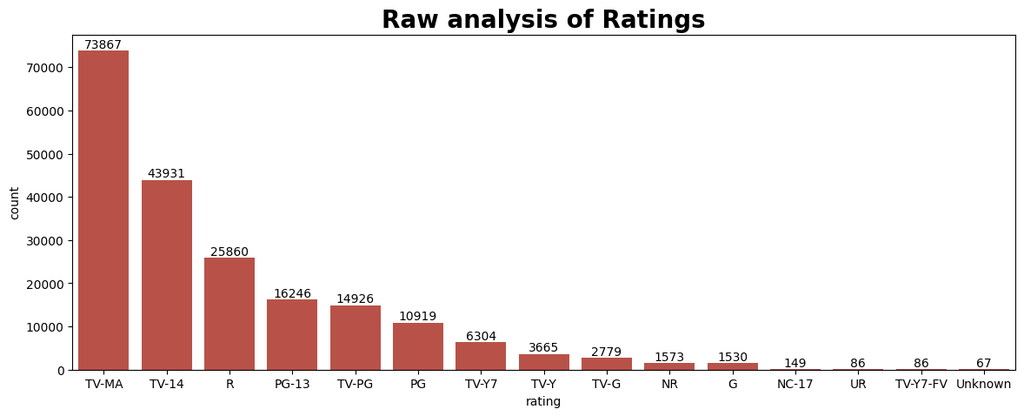

```python
plt.figure(figsize=(14,5))
a = sns.barplot(rvc , x='rating' , y='count' , color='#cb4335' , width=0.8)
plt.title('Raw analysis of Ratings',fontsize=20,fontweight='bold')
a.bar_label(a.containers[0], label_type='edge')
plt.show()
```

```python
df[df.director=='Louis C.K.']
```

|  | show_id | type | title | director | cast | country | date_added | release_year | rating | duration | listed_in | description | year_added |
| --- | --- | --- | --- | --- | --- | --- | --- | --- | --- | --- | --- | --- | --- |
| 126537 | s5542 | Movie | Louis C.K. 2017 | Louis C.K. | Louis C.K. | United States | 2017-04-04 | 2017 | NaN | 74 min | Movies | Louis C.K. muses on religion, eternal love, gi... | 2017 |
| 131603 | s5795 | Movie | Louis C.K.: Hilarious | Louis C.K. | Louis C.K. | United States | 2016-09-16 | 2010 | NaN | 84 min | Movies | Emmy-winning comedy writer Louis C.K. brings h... | 2016 |
| 131737 | s5814 | Movie | Louis C.K.: Live at the Comedy Store | Louis C.K. | Louis C.K. | United States | 2016-08-15 | 2015 | NaN | 66 min | Movies | The comic puts his trademark hilarious/thought... | 2016 |

```python
df.loc[df['director'] == 'Louis C.K.', 'rating'] = 'Unknown'
```

```python
df[df.director=='Louis C.K.']
```

|  | show_id | type | title | director | cast | country | date_added | release_year | rating | duration | listed_in | description | year_added |
| --- | --- | --- | --- | --- | --- | --- | --- | --- | --- | --- | --- | --- | --- |
| 126537 | s5542 | Movie | Louis C.K. 2017 | Louis C.K. | Louis C.K. | United States | 2017-04-04 | 2017 | Unknown | 74 min | Movies | Louis C.K. muses on religion, eternal love, gi... | 2017 |
| 131603 | s5795 | Movie | Louis C.K.: Hilarious | Louis C.K. | Louis C.K. | United States | 2016-09-16 | 2010 | Unknown | 84 min | Movies | Emmy-winning comedy writer Louis C.K. brings h... | 2016 |
| 131737 | s5814 | Movie | Louis C.K.: Live at the Comedy Store | Louis C.K. | Louis C.K. | United States | 2016-08-15 | 2015 | Unknown | 66 min | Movies | The comic puts his trademark hilarious/thought... | 2016 |

```python
df.isna().sum()
```

```
show_id         0
type            0
title           0
director        0
cast            0
country         0
date_added      0
release_year    0
rating          0
duration        0
listed_in       0
description     0
year_added      0
dtype: int64
```

##### 📂we will segregate the data into movie data and tv-shows data and fill the duration appropriately...

```python
df.type.value_counts()
```

```
type
Movie      145843
TV Show     56148
Name: count, dtype: int64
```

```python
movies_data = df[df.type=='Movie']
```

```python
movies_data.shape
```

```
(145843, 13)
```

```python
tvshows_data = df[df.type=='TV Show']
```

```python
tvshows_data.shape
```

```
(56148, 13)
```

```python
movies_data.sample()
```

|  | show_id | type | title | director | cast | country | date_added | release_year | rating | duration | listed_in | description | year_added |
| --- | --- | --- | --- | --- | --- | --- | --- | --- | --- | --- | --- | --- | --- |
| 100089 | s4284 | Movie | Ascharyachakit! | Samit Kakkad | Kashmira Irani | India | 2018-12-19 | 2018 | TV-MA | 90 min | Dramas | Entangling the lives of a movie star, a chauff... | 2018 |

```python
movies_data.isna().sum()
```

```
show_id         0
type            0
title           0
director        0
cast            0
country         0
date_added      0
release_year    0
rating          0
duration        0
listed_in       0
description     0
year_added      0
dtype: int64
```

```python
tvshows_data.sample()
```

|  | show_id | type | title | director | cast | country | date_added | release_year | rating | duration | listed_in | description | year_added |
| --- | --- | --- | --- | --- | --- | --- | --- | --- | --- | --- | --- | --- | --- |
| 105939 | s4550 | TV Show | Monty Python's Almost the Truth | Unknown director | Michael Palin | United Kingdom | 2018-10-02 | 2009 | TV-MA | 1 Season | British TV Shows | The legacy of comedy group Monty Python, whose... | 2018 |

```python
tvshows_data.isna().sum()
```

```
show_id         0
type            0
title           0
director        0
cast            0
country         0
date_added      0
release_year    0
rating          0
duration        0
listed_in       0
description     0
year_added      0
dtype: int64
```

```python
movies_data['runtime_in_mins'] = movies_data['duration'].str.split(' ').str[0]
tvshows_data['no_of_seasons'] = tvshows_data['duration'].str.split(' ').str[0]
```

```python
movies_data.sample()
```

|  | show_id | type | title | director | cast | country | date_added | release_year | rating | duration | listed_in | description | year_added | runtime_in_mins |
| --- | --- | --- | --- | --- | --- | --- | --- | --- | --- | --- | --- | --- | --- | --- |
| 140013 | s6200 | Movie | Automata | Gabe Ibáñez | Christa Campbell | Spain | 2017-09-08 | 2014 | R | 110 min | International Movies | In a dystopian future, an insurance adjuster f... | 2017 | 110 |

```python
movies_data.dtypes
```

```
show_id                    object
type                       object
title                      object
director                   object
cast                       object
country                    object
date_added         datetime64[ns]
release_year                int64
rating                     object
duration                   object
listed_in                  object
description                object
year_added                  int32
runtime_in_mins            object
dtype: object
```

```python
movies_data.runtime_in_mins = movies_data.runtime_in_mins.astype(int)
```

```python
movies_data.dtypes
```

```
show_id                    object
type                       object
title                      object
director                   object
cast                       object
country                    object
date_added         datetime64[ns]
release_year                int64
rating                     object
duration                   object
listed_in                  object
description                object
year_added                  int32
runtime_in_mins             int64
dtype: object
```

```python
movies_data = movies_data.drop(columns=['description','duration']).reset_index(drop=True)
```

```python
movies_data.shape
```

```
(145843, 12)
```

# tvshows....

```python
tvshows_data.tail()
```

|  | show_id | type | title | director | cast | country | date_added | release_year | rating | duration | listed_in | description | year_added | no_of_seasons |
| --- | --- | --- | --- | --- | --- | --- | --- | --- | --- | --- | --- | --- | --- | --- |
| 201864 | s8801 | TV Show | Zindagi Gulzar Hai | Unknown director | Hina Khawaja Bayat | Pakistan | 2016-12-15 | 2012 | TV-PG | 1 Season | Romantic TV Shows | Strong-willed, middle-class Kashaf and carefre... | 2016 | 1 |
| 201865 | s8801 | TV Show | Zindagi Gulzar Hai | Unknown director | Hina Khawaja Bayat | Pakistan | 2016-12-15 | 2012 | TV-PG | 1 Season | TV Dramas | Strong-willed, middle-class Kashaf and carefre... | 2016 | 1 |
| 201932 | s8804 | TV Show | Zombie Dumb | Unknown director | Unknown actors | Unknown | 2019-07-01 | 2018 | TV-Y7 | 2 Seasons | Kids' TV | While living alone in a spooky town, a young g... | 2019 | 2 |
| 201933 | s8804 | TV Show | Zombie Dumb | Unknown director | Unknown actors | Unknown | 2019-07-01 | 2018 | TV-Y7 | 2 Seasons | Korean TV Shows | While living alone in a spooky town, a young g... | 2019 | 2 |
| 201934 | s8804 | TV Show | Zombie Dumb | Unknown director | Unknown actors | Unknown | 2019-07-01 | 2018 | TV-Y7 | 2 Seasons | TV Comedies | While living alone in a spooky town, a young g... | 2019 | 2 |

```python
tvshows_data.no_of_seasons.value_counts()
```

```
no_of_seasons
1     35035
2      9559
3      5084
4      2134
5      1698
7       843
6       633
8       286
9       257
10      220
13      132
12      111
15       96
17       30
11       30
Name: count, dtype: int64
```

```python
tvshows_data.dtypes
```

```
show_id                  object
type                     object
title                    object
director                 object
cast                     object
country                  object
date_added       datetime64[ns]
release_year              int64
rating                   object
duration                 object
listed_in                object
description              object
year_added                int32
no_of_seasons            object
dtype: object
```

```python
tvshows_data.no_of_seasons = tvshows_data.no_of_seasons.astype(int)
```

```python
tvshows_data.no_of_seasons.dtypes
```

```
dtype('int64')
```

```python
tvshows_data = tvshows_data.drop(columns=['description','duration']).reset_index(drop=True)
```

```python
tvshows_data.sample(3)
```

|  | show_id | type | title | director | cast | country | date_added | release_year | rating | listed_in | year_added | no_of_seasons |
| --- | --- | --- | --- | --- | --- | --- | --- | --- | --- | --- | --- | --- |
| 1597 | s255 | TV Show | Go! Go! Cory Carson | Unknown director | Pfifer Chastain | United States | 2021-08-18 | 2021 | TV-Y | Kids' TV | 2021 | 5 |
| 32296 | s3852 | TV Show | Unchained Fate | Unknown director | Rabbit Chen | Unknown | 2019-05-08 | 2016 | TV-14 | TV Dramas | 2019 | 1 |
| 29127 | s3580 | TV Show | Green Frontier | Unknown director | Juana del Río | Colombia | 2019-08-16 | 2019 | TV-MA | Crime TV Shows | 2019 | 1 |

```python
df = df.drop(columns=['description']).reset_index(drop=True)
```

```python
print(f'Cleaned Netflix data has {df.shape[0]} Rows and {df.shape[1]} Columns')
print(f'Netflix Movies data has {movies_data.shape[0]} Rows and {movies_data.shape[1]} Columns')
print(f'Netflix TV shows data has {tvshows_data.shape[0]} Rows and {tvshows_data.shape[1]} Columns')
```

```
Cleaned Netflix data has 201991 Rows and 12 Columns
Netflix Movies data has 145843 Rows and 12 Columns
Netflix TV shows data has 56148 Rows and 12 Columns
```

```python
df.shape
```

```
(201991, 12)
```

```python
df.type.value_counts()
```

```
type
Movie      145843
TV Show     56148
Name: count, dtype: int64
```

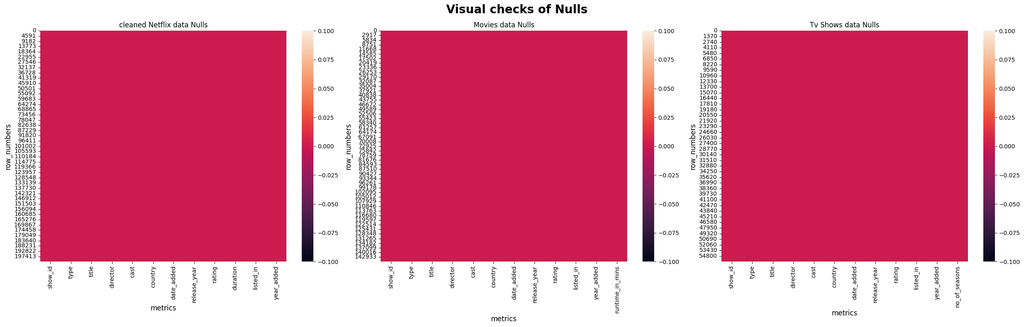

```python
plt.figure(figsize=(25,8), layout='tight').suptitle('Visual checks of Nulls',fontsize=20,fontweight="bold",fontfamily='sans-serif')


plt.subplot(1,3,1)
sns.heatmap(df.isnull())
plt.title('cleaned Netflix data Nulls',fontsize=12)
plt.xlabel('metrics',fontsize=12)
plt.ylabel('row_numbers',fontsize=12)

plt.subplot(1,3,2)
sns.heatmap(movies_data.isnull())
plt.title('Movies data Nulls',fontsize=12)
plt.xlabel('metrics',fontsize=12)
plt.ylabel('row_numbers',fontsize=12)


plt.subplot(1,3,3)
sns.heatmap(tvshows_data.isnull())
plt.title('Tv Shows data Nulls',fontsize=12)
plt.xlabel('metrics',fontsize=12)
plt.ylabel('row_numbers',fontsize=12)

plt.show()
```

#### 👉Insights:

- 👆🏽 #cb4335 color indicates data has 0 % nulls in all columns

```python
# saving the files for further analysis:

df.to_csv('netflix_cleaned_data.csv',sep=',',index=False)
movies_data.to_csv('cleaned_movies_data.csv',sep=',',index=False)
tvshows_data.to_csv('cleaned_tvshows_data.csv',sep=',',index=False)
```

# Exploratory Data Analysis (EDA):

```python
nxd = pd.read_csv('netflix_cleaned_data.csv')
mvd = pd.read_csv('cleaned_movies_data.csv')
tvd = pd.read_csv('cleaned_tvshows_data.csv')
```

```python
nxd.head(5)
```

|  | show_id | type | title | director | cast | country | date_added | release_year | rating | duration | listed_in | year_added |
| --- | --- | --- | --- | --- | --- | --- | --- | --- | --- | --- | --- | --- |
| 0 | s1 | Movie | Dick Johnson Is Dead | Kirsten Johnson | Unknown actors | United States | 2021-09-25 | 2020 | PG-13 | 90 min | Documentaries | 2021 |
| 1 | s2 | TV Show | Blood & Water | Unknown director | Ama Qamata | South Africa | 2021-09-24 | 2021 | TV-MA | 2 Seasons | International TV Shows | 2021 |
| 2 | s2 | TV Show | Blood & Water | Unknown director | Ama Qamata | South Africa | 2021-09-24 | 2021 | TV-MA | 2 Seasons | TV Dramas | 2021 |
| 3 | s2 | TV Show | Blood & Water | Unknown director | Ama Qamata | South Africa | 2021-09-24 | 2021 | TV-MA | 2 Seasons | TV Mysteries | 2021 |
| 4 | s2 | TV Show | Blood & Water | Unknown director | Khosi Ngema | South Africa | 2021-09-24 | 2021 | TV-MA | 2 Seasons | International TV Shows | 2021 |

```python
mvd.head(5)
```

|  | show_id | type | title | director | cast | country | date_added | release_year | rating | listed_in | year_added | runtime_in_mins |
| --- | --- | --- | --- | --- | --- | --- | --- | --- | --- | --- | --- | --- |
| 0 | s1 | Movie | Dick Johnson Is Dead | Kirsten Johnson | Unknown actors | United States | 2021-09-25 | 2020 | PG-13 | Documentaries | 2021 | 90 |
| 1 | s7 | Movie | My Little Pony: A New Generation | Robert Cullen | Vanessa Hudgens | Unknown | 2021-09-24 | 2021 | PG | Children & Family Movies | 2021 | 91 |
| 2 | s7 | Movie | My Little Pony: A New Generation | Robert Cullen | Kimiko Glenn | Unknown | 2021-09-24 | 2021 | PG | Children & Family Movies | 2021 | 91 |
| 3 | s7 | Movie | My Little Pony: A New Generation | Robert Cullen | James Marsden | Unknown | 2021-09-24 | 2021 | PG | Children & Family Movies | 2021 | 91 |
| 4 | s7 | Movie | My Little Pony: A New Generation | Robert Cullen | Sofia Carson | Unknown | 2021-09-24 | 2021 | PG | Children & Family Movies | 2021 | 91 |

```python
# Count total Movies and TV Shows grouped by year
movie_counts_year_add = mvd.groupby(['year_added'])['show_id'].nunique().reset_index()
print(movie_counts_year_add)
```

```
    year_added  show_id
0         2008        1
1         2009        2
2         2010        1
3         2011       13
4         2012        3
5         2013        6
6         2014       19
7         2015       56
8         2016      253
9         2017      839
10        2018     1237
11        2019     1424
12        2020     1284
13        2021      993
```

```python
# Count total Movies and TV Shows grouped by year
movie_counts_rel = mvd.groupby(['release_year'])['show_id'].nunique().reset_index()
print(movie_counts_rel)
```

```
    release_year  show_id
0           1942        2
1           1943        3
2           1944        3
3           1945        3
4           1946        1
..           ...      ...
68          2017      767
69          2018      767
70          2019      633
71          2020      517
72          2021      277

[73 rows x 2 columns]
```

```python
# Count total Movies and TV Shows grouped by year
tvshows_counts_year_add = tvd.groupby(['release_year'])['show_id'].nunique().reset_index()
print(tvshows_counts_year_add)
```

```
    release_year  show_id
0           1925        1
1           1945        1
2           1946        1
3           1963        1
4           1967        1
5           1972        1
6           1974        1
7           1977        1
8           1979        1
9           1981        1
10          1985        1
11          1986        2
12          1988        2
13          1989        1
```

[output cut: 32 more lines]

## ----------------------------------------------------------------------------------------------------------------------------------

- nxd -> Netflix Dataset
- mvd -> Movies Data
- tvd -> TV Shows Data

## ----------------------------------------------------------------------------------------------------------------------------------

#### 📌Q. How are contents distributed in Netflix Platform ?

```python
ntype_gp = nxd.groupby('type')['show_id'].nunique().reset_index()
ntype_gp
```

|  | type | show_id |
| --- | --- | --- |
| 0 | Movie | 6131 |
| 1 | TV Show | 2676 |

```python
from plotly.subplots import make_subplots
import plotly.graph_objects as go

fig = make_subplots(
    rows=1, cols=2,
    subplot_titles=("Netflix Contents Distribution (Pie)", "Netflix Contents Distribution (Bar)"),
    specs=[[{'type':'domain'}, {'type':'xy'}]]
)

# Pie chart
fig.add_trace(
    go.Pie(
        labels=ntype_gp['type'],      # <-- use the 'type' column for labels
        values=ntype_gp['show_id'],
        hole=0,
        marker=dict(colors=['#cb4335', '#dedede']),
        pull=[0.08, 0],
        textinfo='percent+label',
        textfont=dict(color='black')
    ),
    row=1, col=1
)

# Bar chart
fig.add_trace(
    go.Bar(
        x= ntype_gp['type'],
        y= ntype_gp['show_id'],
        marker_color=['#cb4335', '#dedede'],
        text= ntype_gp['show_id'],
        textposition='outside'
    ),
    row=1, col=2
)

fig.update_layout(
    title_text="Netflix Contents Distribution",
    showlegend=False,
    height=600,
    width=1200
)
fig.update_yaxes(showticklabels=False, title_text='', row=1, col=2)
fig.show()
```

[interactive chart not shown]

#### 👉Insights :

- we can clearly interpret that nearly *70%* contents are `Movies` whereas *30%* are `Tvshows` contents in **Netflix** content library.

#### 📌Q. Outliers check:

```python
from plotly.subplots import make_subplots

import plotly.graph_objects as go

# Prepare data for violin and box plots
types = nxd['type'].unique()
colors = ['#cb4335', "#A2A1A1"]

fig = make_subplots(
    rows=1, cols=2,
    subplot_titles=("Violin Distribution", "Box & Whisker Distribution"),
    shared_yaxes=True
)

# Violin plots
for idx, t in enumerate(types):
    fig.add_trace(
        go.Violin(
            x=nxd[nxd['type'] == t]['type'],
            y=nxd[nxd['type'] == t]['release_year'],
            name=t,
            line_color=colors[idx],
            fillcolor=colors[idx],
            opacity=0.7,
            box_visible=True,
            meanline_visible=True,
            showlegend=False
        ),
        row=1, col=1
    )

# Box plots
for idx, t in enumerate(types):
    fig.add_trace(
        go.Box(
            x=nxd[nxd['type'] == t]['type'],
            y=nxd[nxd['type'] == t]['release_year'],
            name=t,
            marker_color=colors[idx],
            boxmean=True,
            showlegend=False
        ),
        row=1, col=2
    )

fig.update_layout(
    height=800,
    width=1500,
    title_text="Netflix Contents Distribution",
    margin=dict(t=80),
)

fig.update_xaxes(title_text="", row=1, col=1)
fig.update_xaxes(title_text="", row=1, col=2)
fig.update_yaxes(title_text="Release Year", row=1, col=1)
fig.update_yaxes(title_text="", row=1, col=2)

fig.show()
```

[interactive chart not shown]

#### 👉Insights :

- Here we can easily identify that the contents released before 1960 are the outliers.

#### 📌Q. In which year maximum contents got released ?

```python
import plotly.express as px

# Filter for years 1998 to 2021
filtered = nxd[(nxd['release_year'] >= 1998) & (nxd['release_year'] <= 2021)]

# Group by year and type, count unique show_id
year_type_counts = (
    filtered.groupby(['release_year', 'type'])['show_id']
    .nunique()
    .reset_index(name='content_count')
    .sort_values('release_year')
)

# Plot
fig = px.line(
    year_type_counts,
    x='release_year',
    y='content_count',
    color='type',
    markers=True,
    title='Content Released Each Year (2000–2021)',
    labels={'release_year': 'Year Added', 'content_count': 'Number of Contents', 'type': 'Content Type'},
    color_discrete_map={'Movie': '#CB4335', 'TV Show': '#A2A1A1'},
    line_shape = 'spline',
)

fig.update_layout(
    width=1200,
    height=700,
    xaxis=dict(
        tickmode='linear',
        dtick=1
    )
)
fig.show()
```

[interactive chart not shown]

```python
import plotly.express as px

# Filter for years 1998 to 2021
filtered = nxd[(nxd['year_added'] >= 1998) & (nxd['year_added'] <= 2021)]

# Group by year and type, count unique show_id
year_type_counts = (
    filtered.groupby(['year_added', 'type'])['show_id']
    .nunique()
    .reset_index(name='content_count')
    .sort_values('year_added')
)

# Plot
fig = px.line(
    year_type_counts,
    x='year_added',
    y='content_count',
    color='type',
    markers=True,
    title='Content Added on Netflix Each Year (2000–2021)',
    labels={'year_added': 'Year Added', 'content_count': 'Number of Contents', 'type': 'Content Type'},
    color_discrete_map={'Movie': '#CB4335', 'TV Show': '#A2A1A1'},
    line_shape = 'spline',
)

fig.update_layout(
    width=1200,
    height=700,
    xaxis=dict(
        tickmode='linear',
        dtick=1
    )
)
fig.show()
```

[interactive chart not shown]

#### 👉Insights :

- Between 2015 and 2016, Netflix saw a drastic increase in the number of movies and TV shows releases, marking a significant jump in content production or acquisitions. This surge was followed by a steady upward trend until 2019, reflecting continued investment in expanding the platform's movie catalog.
- However, starting from 2019, the number of movies released dropped sharply—likely due to the global impact of the COVID-19 pandemic on film production and distribution. This disruption appears as a clear dip in the trend, contrasting with the prior growth pattern.

```python
import plotly.express as px

# Calculate top 15 countries by unique movie count, excluding 'Unknown'
cwm = (
    mvd[mvd['country'] != 'Unknown']
    .groupby('country')['show_id']
    .nunique()
    .nlargest(10)
    .sort_values(ascending=True)  # ascending for reversed y-axis
    .reset_index()
    .rename(columns={'show_id': 'movie_count'})
)

# Plot horizontal bar chart
fig = px.bar(
    cwm,
    x='movie_count',
    y='country',
    orientation='h',
    title='Top 15 Countries by Unique Netflix Movies',
    labels={'movie_count': 'Number of Movies', 'country': 'Country'},
    color_discrete_sequence=['#CB4335'],
    category_orders={'country': cwm['country'].tolist()}
)

fig.update_layout(
    width=1200,
    height=700,
    yaxis=dict(autorange='reversed')
)

fig.show()
```

[interactive chart not shown]

```python
# Calculate top 15 countries by unique movie count, excluding 'Unknown'
ctv = (
    tvd[tvd['country'] != 'Unknown']
    .groupby('country')['show_id']
    .nunique()
    .nlargest(10)
    .sort_values(ascending=True)  # ascending for reversed y-axis
    .reset_index()
    .rename(columns={'show_id': 'tvshows_count'})
)

# Plot horizontal bar chart
fig = px.bar(
    ctv,
    x='tvshows_count',
    y='country',
    orientation='h',
    title='Top 15 Countries by Unique Netflix TV Shows',
    labels={'tvshows_count': 'Number of Movies', 'country': 'Country'},
    color_discrete_sequence=['#CB4335'],
    category_orders={'country': ctv['country'].tolist()}
)

fig.update_layout(
    width=1200,
    height=700,
    yaxis=dict(autorange='reversed')
)

fig.show()
```

[interactive chart not shown]

```python
common_countries = set(cwm['country']).intersection(ctv['country'])

# Filter both to common countries
cwm_aligned = cwm[cwm['country'].isin(common_countries)].reset_index(drop=True)

ctv_aligned = ctv[ctv['country'].isin(common_countries)]

# Reorder ctv_aligned to the same country order as cwm_aligned
ctv_aligned = ctv_aligned.set_index('country').loc[cwm_aligned['country']].reset_index()

# Now check order again:
print(list(cwm_aligned['country']) == list(ctv_aligned['country']))  # should be True
```

```
True
```

```python
import plotly.graph_objects as go

top_n = len(cwm_aligned)
indices = list(range(top_n))

fig = go.Figure()

# Movies bars
fig.add_trace(go.Bar(
    x=indices,
    y=cwm_aligned['movie_count'],
    name='Movies',
    marker_color='#cb4335',
    width=0.4,
    text=cwm_aligned['movie_count'],
    textposition='outside'
))

# TV Shows bars
fig.add_trace(go.Bar(
    x=indices,
    y=ctv_aligned['tvshows_count'],
    name='TV Shows',
    marker_color='#A2A1A1',
    width=0.4,
    text=ctv_aligned['tvshows_count'],
    textposition='outside'
))

fig.update_layout(
    title='Countries Consuming Movies & TV Shows',
    xaxis=dict(
        tickmode='array',
        tickvals=indices,
        ticktext=cwm_aligned['country'],
        title='Country'
    ),
    yaxis_title='Content Count',
    barmode='group',
    legend=dict(
        orientation='h',   # horizontal legend
        yanchor='bottom',
        y=1.08,            # move legend above plot
        xanchor='center',
        x=0.5
    ),
    width=1200,
    height=600,
    font=dict(family='sans-serif', size=13),
    margin=dict(t=80, l=60, r=30, b=80)
)

fig.show()
```

[interactive chart not shown]

#### 👉Insights :

- The top 5 countries with the highest count of Movies and TV Shows are aiding in recognizing the key players in TV show production and Movies production.
- We can infer that `US` , `India` , `UK` are the top entertainment consumers while other countries significantly contribute to the OTT content library.